# Competences ERPI

## Goal

> To have an averview of the ERPI laboratory.

### Keywords (PhD survey)

The ERPI laboratory according to PhD. students:

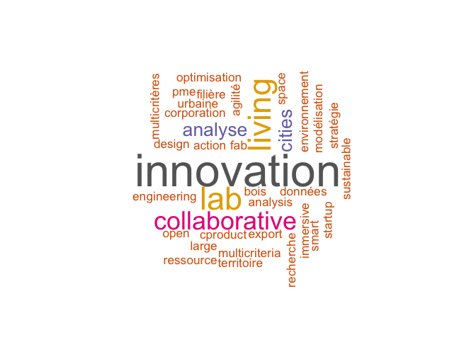

## Keywords (from HAL)

We took the HAL publications from ERPI in the period 2018-2019, to explore the keywords and the journals.

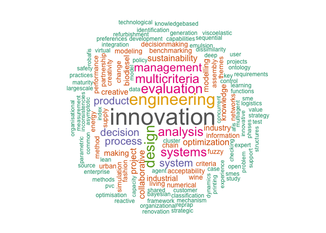

### Journals

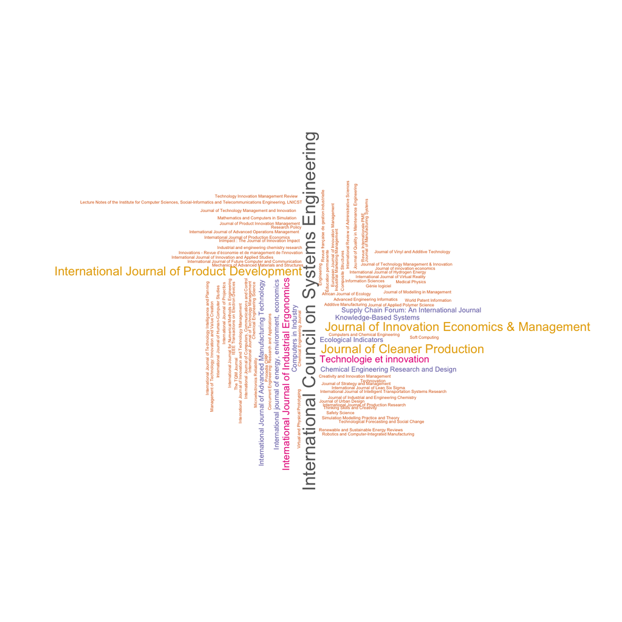

|  | Journal | Quantity |
| --- | --- | --- |
| 1 | International Council on Systems Engineering | 6 |
| 2 | International Journal of Product Development | 4 |
| 3 | Journal of Cleaner Production | 4 |
| 4 | Journal of Innovation Economics &amp; Management | 4 |
| 5 | International Journal of Industrial Ergonomics | 3 |
| 6 | Technologie et innovation | 3 |
| 7 | Chemical Engineering Research and Design | 2 |
| 8 | Computers in Industry | 2 |
| 9 | Ecological Indicators | 2 |
| 10 | International Journal of Advanced Manufacturing Technology | 2 |

[output cut: 73 more lines]

## ERPI Competences

### Cadre de compéténces

[Arrêté du 22 février 2019 définissant les compétences des diplômés du doctorat et inscrivant le doctorat au répertoire national de la certification professionnelle](https://www.legifrance.gouv.fr/affichTexte.do?cidTexte=JORFTEXT000038200990&dateTexte=&categorieLien=id)

Bloc 1 Conception et élaboration d’une démarche de recherche et développement, d’études et prospective

- disposer d’une expertise scientifique tant générale que spécifique d’un domaine de recherche et de travail déterminé ;
- faire le point sur l’état et les limites des savoirs au sein d’un secteur d’activité déterminé, aux échelles locale, nationale et internationale ;
- identifier et résoudre des problèmes complexes et nouveaux impliquant une pluralité de domaines, en mobilisant les connaissances et les savoir-faire les plus avancés ;
- identifier les possibilités de ruptures conceptuelles et concevoir des axes d’innovation pour un secteur professionnel ;
- apporter des contributions novatrices dans le cadre d’échanges de haut niveau, et dans des contextes internationaux ;
- s’adapter en permanence aux nécessités de recherche et d’innovation au sein d’un secteur professionnel.

Bloc 2 Mise en œuvre d’une démarche de recherche et développement, d’études et prospective

- mettre en œuvre les méthodes et les outils de la recherche en lien avec l’innovation ;
- mettre en œuvre les principes, outils et démarches d’évaluation des coûts et de financement d’une démarche d’innovation ou de R&D ;
- garantir la validité des travaux ainsi que leur déontologie et leur confidentialité en mettant en œuvre les dispositifs de contrôle adaptés ;
- gérer les contraintes temporelles des activités d’études, d’innovation ou de R&D ;
- mettre en œuvre les facteurs d’engagement, de gestion des risques et d’autonomie nécessaire à la finalisation d’un projet R&D, d’études ou d’innovation.

Bloc 3 Valorisation et transfert des résultats d’une démarche R&D, d’études et prospective

- mettre en œuvre les problématiques de transfert à des fins d’exploitation et valorisation des résultats ou des produits dans des secteurs économiques ou sociaux ;
- respecter les règles de propriété intellectuelle ou industrielle liées à un secteur ;
- respecter les principes de déontologie et d’éthique en relation avec l’intégrité des travaux et les impacts potentiels ;
- mettre en œuvre l’ensemble des dispositifs de publication à l’échelle internationale permettant de valoriser les savoirs et connaissances nouvelles ;
- mobiliser les techniques de communication de données en « open data » pour valoriser des démarches et résultats.

Bloc 4 Veille scientifique et technologique à l’échelle internationale

- acquérir, synthétiser et analyser les données et informations scientifiques et technologiques d’avant-garde à l’échelle internationale ;
- disposer d’une compréhension, d’un recul et d’un regard critique sur l’ensemble des informations de pointe disponibles ;
- dépasser les frontières des données et du savoir disponibles par croisement avec différents champs de la connaissance ou autres secteurs professionnels ;
- développer des réseaux de coopération scientifiques et professionnels à l’échelle internationale ;
- disposer de la curiosité, de l’adaptabilité et de l’ouverture nécessaire pour se former et entretenir une culture générale et internationale de haut niveau.

Bloc 5 Formation et diffusion de la culture scientifique et technique

- rendre compte et communiquer en plusieurs langues des travaux à caractère scientifique et technologique en direction de publics ou publications différents, à l’écrit comme à l’oral ;
- enseigner et former des publics diversifiés à des concepts, outils et méthodes avancés ;
- s’adapter à un public varié pour communiquer et promouvoir des concepts et démarches d’avant-garde.

Bloc 6 Encadrement d’équipes dédiées à des activités de recherche et développement, d’études et prospective

- animer et coordonner une équipe dans le cadre de tâches complexes ou interdisciplinaires ;
- repérer les compétences manquantes au sein d’une équipe et participer au recrutement ou à la sollicitation de prestataires ;
- construire les démarches nécessaires pour impulser l’esprit d’entrepreneuriat au sein d’une équipe ;
- identifier les ressources clés pour une équipe et préparer les évolutions en termes de formation et de développement personnel ;
- évaluer le travail des personnes et de l’équipe vis à vis des projets et objectifs.

## Results

In the foollowing table you can find the results from the survey aout the comptences.

|  | People | Competence | Level |
| --- | --- | --- | --- |
| 1 | Mauricio CAMARGO | CR-1 | 1- Novice |
| 2 | Laurent DUPONT | CR-1 | 3- Compétent |
| 3 | Maxence ARNOULD | CR-1 | 1- Novice |
| 4 | Manon Enjolras | CR-1 | 3- Compétent |
| 5 | Jonathan LACROIX | CR-1 | 2- Débutant avancé |
| 6 | Brunelle MARCHE | CR-1 | 3- Compétent |
| 7 | Alice de Bigault de Casanove | CR-1 | 3- Compétent |
| 8 | Mauricio CAMARGO | CR-2 | 2- Débutant avancé |
| 9 | Laurent DUPONT | CR-2 | 3- Compétent |
| 10 | Maxence ARNOULD | CR-2 | 3- Compétent |

[output cut: 193 more lines]